# explanation of insert() and delMin()

### insert()

As for insert(), it's a method defined inside binaryHeap() class, take self and node two arguments.  
At first, it transform node into linked list node and append it into the linked list. append() is a method for add element in linked list.  
Then,it adopt size() method (a method for linked list size) to get new element index  
Next, it use swim() method to float the new element in the bottom of heap.

In the swim() method, it apply getNode() to convert the index into a node. So, I can get the the node and its parent node.  
Then in order to have a smaller value in parent node, it compare node's value and its parent node's value.  
In while loop, if the node's value is less than its parent node's value, their value will be exchanged.  
Afterwards, Change the index of this node to the index of its parent node. The exchange function will be continuously excutived if it satisfies the compare comdition in while loop.

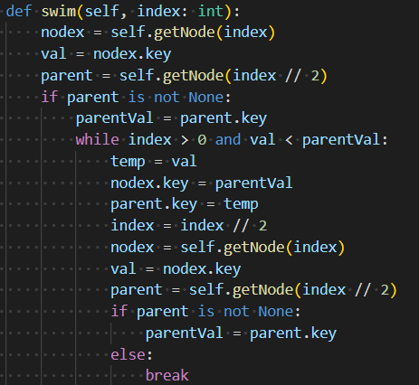

### delMin()

As for delMin(), it traverse the linked list to get the last node and the second last node. Then, it output the minimum value and replace the head's value with the last node's value.  
Next, it use the second last node to delete the last node. Lastly, it use sink() method to sink the head's value so as to rebuild the heap's order.

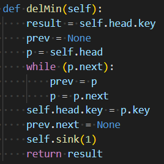

Then in the sink() method, it use getNode() method to transfrom index into node. It use while loop to switch to its children. There are several boundary conditions. If the left chid is just the last node, then it will compare its value with its left child's value. If its value is bigger than its left child's value, then swap their value and break the loop.  
If its value is bigger than the smaller value of its children, then swap its value with the smaller value of its children, change index from this node to the child with smaller value, and continue the while-loop with new index. If its value is less than the smaller value of its children, break the loop.

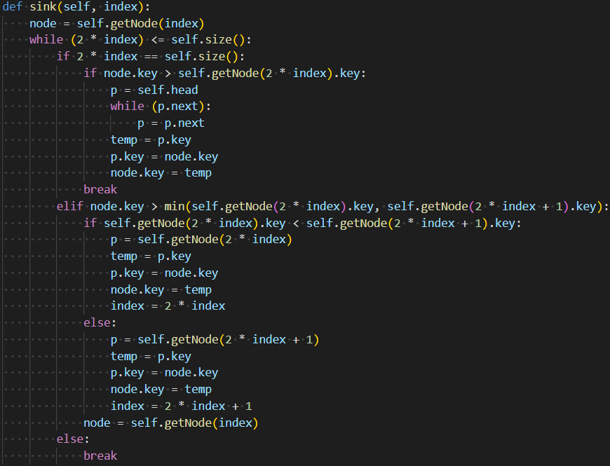

# Time complexity if insert() and delMin()

### insert()

As for insert(), the size() method and append() method all traverse the linked list, the time complexity for them is O(n) In the swim() method, it use getNode()(traverse linked list to get node) to transform the index into the node, whose complexity is O(n)  
Afterwards, it use while loop to switch to node's parent from bottom to top. Since it's a binary heap, the height is log<sub>2</sub>n.  
Thus, the time complexity in swim() is O(nlog<sub>2</sub>n). As a result the total time complexity in insert() is O(nlog<sub>2</sub>n)

##### delMin()

As for delMin(), it traverse the linked list to replace and delete, the time complexity of traverse is O(n).  
Then, it use the sink() method to sink the top node in order to get minimum value in top node.  
At first,it use getNode()(traverse linked list to get node) to transform the index into the node, whose complexity is O(n)  
Then, it use while-loop to switch to node's child from top to bottom. The while-loop's time complexity is O(log<sub>2</sub>n)  
In the while-loop, it use traverse technique to get node and swap, whose time complexity is O(n)  
Thus, the time complexity in sink() is O(nlog<sub>2</sub>n). As a result , the total time complexity in delMin() is O(nlog<sub>2</sub>n)

# Test and pic

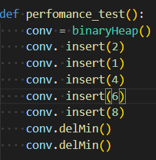

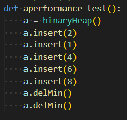

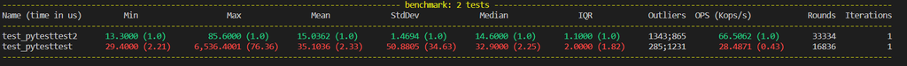

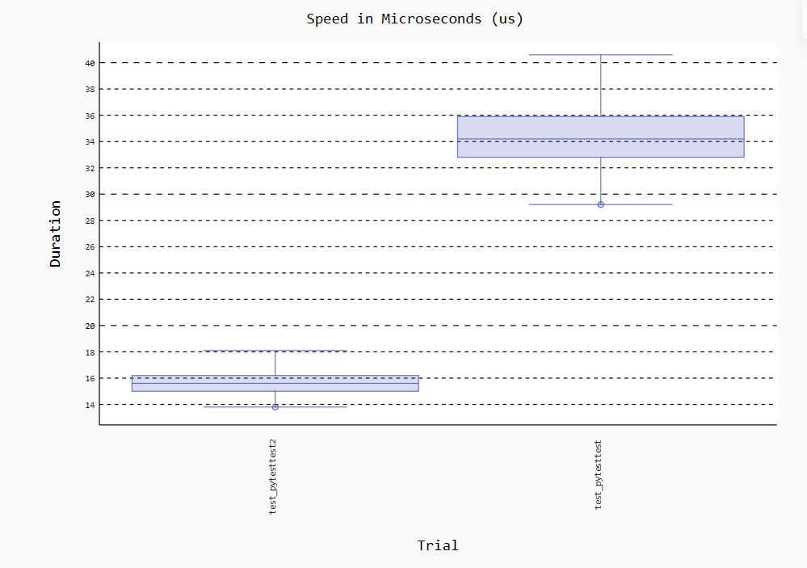

# Graphviz

the heap can be explain by complete binary tree node form ,where tree node attribute is used.(left) And linked list node form directly, where tree node attribute is implict.(right)

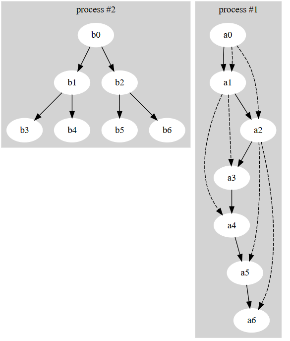

github address:https://github.com/zavailble/dataStructureCourse